# Data Programming Project

William Imbert

2023-06-16

## 1. Introduction

Lego is one of the most popular toy brands in the world. Everyone has already heard about the famous Lego bricks and sets, at the point where in Christmas period, approximately 28 Lego sets are sold each second ! The brand was created in 1932, started production of bricks in 1949 and have since been growing more and more to become the largest toy brand by revenue. The Lego sets are a big part of the childhood of many people, including me, and a lot of adult people never lost interest in their passion for Legos, creating amazing constructions (called MOC: My Own Creation), CAD softwares just for Legos or amazing websites where we can find second-hand parts or MOC instructions. A quick look at all the Lego community managed to build make us understand that this community is truly amazing and full of dedication. Some even did a gigantic job of referencing every single Lego part, set and figurines to make a free Dataset containing all of this data. With the symbol that Lego toys represent for many people, it is obviously very interesting to take a close look at this Lego data and try to extract interesting facts about all the sets and parts of the iconic brand.

## 2. Presentation of the data

The dataset was taken from the Rebrickable website which is one of the most popular third-party Lego website, referencing thousands of MOC instructions as well as all official Lego sets and parts. It allows Lego fans to find the cheapest places to buy Lego parts and is for Lego enthusiasts a place to share their passion. Here is the Schema Diagram of the dataset provided by Rebrickable:

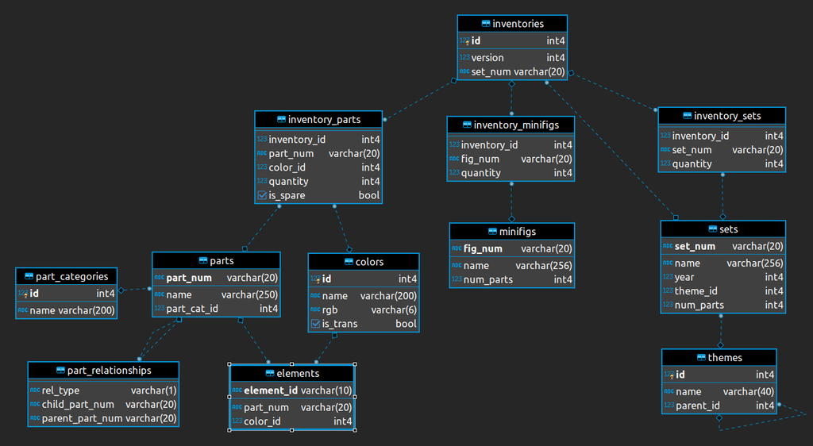

The `inventories` table can be seen as the central part of the dataset. Every inventory is linked to a set, with its name, year, theme_id and nb of parts. Every set has a category, which can for example be `Technic`, one of the most iconic Lego themes. An inventory can also be linked to `inventory_sets`(a single inventory linked to one set can contain multiple set), `inventory_minifigs` (which references the all minifigures contained in an inventory) and `inventory_parts` (which references all the parts contained in an inventory, along with its color and quantity). The `parts`, `colors`, `part_categories`, `parts relationships` and `elements`tables give us more informations on the parts used in the inventories, and the same is for `minifigs`, which give us informations about the Lego figurines.

All tables are downloadable in `csv.gz` format and we can then use them in R by creating a list of all the datasets using the `read.csv` function. Note that we had to put all the `csv.gz` files in a `data` directory.

```r
lego <- list(colors = read.csv("data/colors.csv.gz"),
             elements = read.csv("data/elements.csv.gz"),
             inventories = read.csv("data/inventories.csv.gz"),
             inventory_minifigs = read.csv("data/inventory_minifigs.csv.gz"),
             inventory_parts = read.csv("data/inventory_parts.csv.gz"),
             inventory_sets = read.csv("data/inventory_sets.csv.gz"),
             minifigs = read.csv("data/minifigs.csv.gz"),
             part_categories = read.csv("data/part_categories.csv.gz"),
             part_relationships = read.csv("data/part_relationships.csv.gz"),
             parts = read.csv("data/parts.csv.gz"),
             sets = read.csv("data/sets.csv.gz"),
             themes = read.csv("data/themes.csv.gz"))
```

## 3. Aggregation of data

### Sets that have the most parts

We can easily get the sets that have the most parts:

```r
lego$sets %>%
  inner_join(lego$themes, by = c("theme_id" = "id")) %>%
  select(set_num, set_name=name.x, year, theme=name.y, num_parts) %>%
  arrange(desc(num_parts)) %>%
  slice_head(n = 10)
```

```
##     set_num                      set_name year                     theme
## 1   31203-1                     World Map 2021                  LEGO Art
## 2   10307-1                  Eiffel Tower 2022                     Icons
## 3  BIGBOX-1 The Ultimate Battle for Chima 2015          Legends of Chima
## 4   10294-1                       Titanic 2021                     Icons
## 5   10276-1                     Colosseum 2020                     Icons
## 6   75192-1             Millennium Falcon 2017 Ultimate Collector Series
## 7   75313-1                         AT-AT 2021 Ultimate Collector Series
## 8   75331-1               The Razor Crest 2022 Ultimate Collector Series
## 9   10316-1  Lord of the Rings: Rivendell 2023                     Icons
## 10  71043-1               Hogwarts Castle 2018              Harry Potter
##    num_parts
## 1      11695
## 2      10001
## 3       9987
## 4       9092
## 5       9036
## 6       7541
## 7       6785
## 8       6194
## 9       6182
## 10      6020
```

### Retrieve all parts contained in a Lego set

```r
get_set_parts <- \(set_number, set_version = 1, spare_parts = FALSE) {
  lego$inventories %>%
    dplyr::filter(set_num == str_c(set_number, '-', set_version, sep = ''), version == set_version) %>%
    inner_join(lego$inventory_parts, by = c("id" = "inventory_id")) %>%
    dplyr::filter(grepl(ifelse(spare_parts, "[tf]", "f"), is_spare)) %>%
    inner_join(lego$parts, by = c("part_num" = "part_num")) %>%
    inner_join(lego$colors, by = c("color_id" = "id")) %>%
    inner_join(lego$part_categories, by = c("part_cat_id" = "id")) %>%
    select(part_num, name = name.x, quantity, category = name, color = name.y) %>%
    arrange(desc(quantity))
}
```

The function takes as arguments the set number (present on all sets), the set version (generally there is only one, but in some rare cases there can be multiple, for example when there are some randomness in the set) and finally the spare parts, which does not appear by default.

Here are the parts of some of the most popular Lego sets: - The World Map (set with the most parts):

```r
get_set_parts(31203) %>% datatable()
```

|  | part_num | name | quantity | category | color |
| --- | --- | --- | --- | --- | --- |
| 1 | 6141 | Plate Round 1 x 1 with Solid Stud | 3064 | Plates Round Curved and Dishes | White |
| 2 | 98138 | Tile Round 1 x 1 | 1879 | Tiles Round and Curved | Dark Turquoise |
| 3 | 98138 | Tile Round 1 x 1 | 1607 | Tiles Round and Curved | Medium Azure |
| 4 | 98138 | Tile Round 1 x 1 | 1060 | Tiles Round and Curved | Lime |
| 5 | 98138 | Tile Round 1 x 1 | 725 | Tiles Round and Curved | Tan |
| 6 | 98138 | Tile Round 1 x 1 | 601 | Tiles Round and Curved | Bright Green |
| 7 | 98138 | Tile Round 1 x 1 | 601 | Tiles Round and Curved | Coral |
| 8 | 98138 | Tile Round 1 x 1 | 601 | Tiles Round and Curved | Orange |
| 9 | 98138 | Tile Round 1 x 1 | 599 | Tiles Round and Curved | Bright Light Orange |
| 10 | 98138 | Tile Round 1 x 1 | 393 | Tiles Round and Curved | Dark Blue |

[output cut: 22 more lines]

- The Eiffel Tower, which has the second most parts and maybe the most iconic set:

```r
get_set_parts(10307) %>% datatable()
```

|  | part_num | name | quantity | category | color |
| --- | --- | --- | --- | --- | --- |
| 1 | 60897 | Plate Special 1 x 1 with Clip Vertical [Thick Open O Clip] | 704 | Plates Special | Dark Bluish Gray |
| 2 | 3666 | Plate 1 x 6 | 666 | Plates | Dark Bluish Gray |
| 3 | 23443 | Bar Holder with Hole and Bar Handle | 660 | Bars, Ladders and Fences | Dark Bluish Gray |
| 4 | 3023 | Plate 1 x 2 | 390 | Plates | Dark Bluish Gray |
| 5 | 37762 | Equipment Candle Stick | 345 | Minifig Accessories | Dark Bluish Gray |
| 6 | 6141 | Plate Round 1 x 1 with Solid Stud | 284 | Plates Round Curved and Dishes | Dark Bluish Gray |
| 7 | 3024 | Plate 1 x 1 | 268 | Plates | Dark Bluish Gray |
| 8 | 24866 | Plant, Flower, Plate Round 1 x 1 with 5 Petals | 264 | Plants and Animals | Green |
| 9 | 78258 | Bar 2L with Stop in Center | 256 | Bars, Ladders and Fences | Dark Bluish Gray |
| 10 | 3623 | Plate 1 x 3 | 204 | Plates | Dark Bluish Gray |

[output cut: 267 more lines]

- Liebherr R 9800 Excavator: one of the iconic Lego Technic sets with number 42100:

```r
get_set_parts(42100) %>% datatable
```

|  | part_num | name | quantity | category | color |
| --- | --- | --- | --- | --- | --- |
| 1 | 2780 | Technic Pin with Friction Ridges Lengthwise and Center Slots | 629 | Technic Pins | Black |
| 2 | 6558 | Technic Pin Long with Friction Ridges Lengthwise, 2 Center Slots | 380 | Technic Pins | Blue |
| 3 | 43093 | Technic Axle Pin with Friction Ridges Lengthwise | 229 | Technic Pins | Blue |
| 4 | 11214 | Technic Axle Pin 3L with Friction Ridges Lengthwise and 1L Axle | 105 | Technic Pins | Red |
| 5 | 88323 | Technic Link Tread Wide with Two Pin Holes, Reinforced | 104 | Technic Special | Dark Bluish Gray |
| 6 | 3941 | Brick Round 2 x 2 with Axle Hole | 102 | Bricks Round and Cones | Dark Bluish Gray |
| 7 | 59443 | Technic Axle Connector Smooth [with x Hole + Orientation] | 98 | Technic Connectors | Dark Bluish Gray |
| 8 | 2412b | Tile Special 1 x 2 Grille with Bottom Groove | 80 | Tiles Special | White |
| 9 | 32062 | Technic Axle 2 Notched | 80 | Technic Axles | Red |
| 10 | 4519 | Technic Axle 3 | 73 | Technic Axles | Light Bluish Gray |

[output cut: 215 more lines]

### Most used parts depending on the theme

```r
most_used_parts_theme <- \(themes_id = lego$themes$id) {
  lego$sets %>%
    dplyr::filter(theme_id %in% c(themes_id)) %>%
    select(set_num) %>%
    inner_join(lego$inventories, by = c("set_num" = "set_num")) %>%
    inner_join(lego$inventory_parts, by = c("id" = "inventory_id")) %>%
    filter(version == 1) %>%
    inner_join(lego$parts, by = c("part_num" = "part_num")) %>%
    select(num = part_num, name, quantity) %>%
    group_by(num, name) %>%
    summarize(quantity = sum(quantity)) %>%
    arrange(desc(quantity)) %>%
    ungroup
}
```

This function simply takes the theme id (we can find it using the `themes` table) and returns a list of the most used parts with this theme. We can put multiple themes id as arguments and by default it the `themes_id` take the ids of all themes.

Most used parts in general:

```r
most_used_parts_theme() %>%
  mutate(prop=.$quantity/sum(.$quantity)*100) %>%
  slice_head(n=10)
```

```
## # A tibble: 10 × 4
##    num   name                                                     quantity  prop
##    <chr> <chr>                                                       <int> <dbl>
##  1 3023  Plate 1 x 2                                                109283  3.26
##  2 6141  Plate Round 1 x 1 with Solid Stud                          105468  3.15
##  3 3004  Brick 1 x 2                                                 90229  2.69
##  4 3024  Plate 1 x 1                                                 81804  2.44
##  5 3005  Brick 1 x 1                                                 66659  1.99
##  6 2780  Technic Pin with Friction Ridges Lengthwise and Center …    58475  1.75
##  7 3003  Brick 2 x 2                                                 51639  1.54
##  8 3710  Plate 1 x 4                                                 49319  1.47
##  9 98138 Tile Round 1 x 1                                            46640  1.39
## 10 54200 Slope 30° 1 x 1 x 2/3 (Cheese Slope)                        43002  1.28
```

Most used Lego Technic parts:

```r
most_used_parts_theme(1) %>%
  mutate(prop=.$quantity/sum(.$quantity)*100) %>%
  slice_head(n=10)
```

```
## # A tibble: 10 × 4
##    num   name                                                     quantity  prop
##    <chr> <chr>                                                       <int> <dbl>
##  1 2780  Technic Pin with Friction Ridges Lengthwise and Center …    24658 10.9
##  2 6558  Technic Pin Long with Friction Ridges Lengthwise, 2 Cen…    11265  5.00
##  3 43093 Technic Axle Pin with Friction Ridges Lengthwise             7775  3.45
##  4 4519  Technic Axle 3                                               5426  2.41
##  5 61332 Technic Pin with Friction Ridges Lengthwise with No Cen…     5301  2.35
##  6 3713  Technic Bush                                                 5032  2.23
##  7 32062 Technic Axle 2 Notched                                       4915  2.18
##  8 6536  Technic Axle and Pin Connector Perpendicular                 4601  2.04
##  9 4274  Technic Pin 1/2                                              3870  1.72
## 10 32054 Technic Pin Long with Friction Ridges Lengthwise and St…     3863  1.71
```

Most used Lego Creator parts:

```r
most_used_parts_theme(22) %>%
  mutate(prop=.$quantity/sum(.$quantity)*100) %>%
  slice_head(n=10)
```

```
## # A tibble: 10 × 4
##    num   name        quantity  prop
##    <chr> <chr>          <int> <dbl>
##  1 3004  Brick 1 x 2     4729 14.1
##  2 3003  Brick 2 x 2     4235 12.6
##  3 3005  Brick 1 x 1     3161  9.42
##  4 3001  Brick 2 x 4     2043  6.09
##  5 3010  Brick 1 x 4     1419  4.23
##  6 3002  Brick 2 x 3     1313  3.91
##  7 3022  Plate 2 x 2      630  1.88
##  8 3023  Plate 1 x 2      587  1.75
##  9 3009  Brick 1 x 6      537  1.60
## 10 3622  Brick 1 x 3      516  1.54
```

Using the mutate function, I also added the proportion in % of the most used parts.

### Most used colors depending on the set/theme/part

Using the `elements` table, we can get the parts that have the most color variations:

```r
lego$elements %>%
  inner_join(lego$parts, by = c("part_num" = "part_num")) %>%
  group_by(part_num, name) %>%
  count() %>%
  arrange(desc(n)) %>%
  ungroup %>%
  slice_head(n=10)
```

```
## # A tibble: 10 × 3
##    part_num name                                  n
##    <chr>    <chr>                             <int>
##  1 3023     Plate 1 x 2                         153
##  2 3005     Brick 1 x 1                         141
##  3 3024     Plate 1 x 1                         138
##  4 3004     Brick 1 x 2                         119
##  5 3020     Plate 2 x 4                         119
##  6 3001     Brick 2 x 4                         116
##  7 3010     Brick 1 x 4                         114
##  8 3021     Plate 2 x 3                         110
##  9 6141     Plate Round 1 x 1 with Solid Stud   109
## 10 3003     Brick 2 x 2                         105
```

We can also get the sets that have the most different colors:

```r
lego$sets %>%
  inner_join(lego$inventories, by=c("set_num"="set_num")) %>%
  inner_join(lego$inventory_parts, by=c("id" = "inventory_id")) %>%
  group_by(set_num, name) %>%
  distinct(color_id) %>%
  count %>%
  arrange(desc(n)) %>%
  ungroup %>%
  slice_head(n=10)
```

```
## # A tibble: 10 × 3
##    set_num  name                                  n
##    <chr>    <chr>                             <int>
##  1 70620-1  NINJAGO City                         53
##  2 71741-1  NINJAGO City Gardens                 52
##  3 10717-1  Bricks Bricks Bricks                 49
##  4 11717-1  Bricks Bricks Plates                 49
##  5 80036-1  The City of Lanterns                 49
##  6 75978-1  Diagon Alley                         48
##  7 910027-1 Mountain View Observatory            48
##  8 41732-1  Downtown Flower and Design Stores    46
##  9 10292-1  Friends - The Apartments             45
## 10 21324-1  123 Sesame Street                    45
```

### Analysis on figurines

In total, there are 13148 figurines.

Here are the sets that have the most minifigs:

```r
lego$inventory_minifigs %>%
  inner_join(lego$inventories, by = c("inventory_id" = "id")) %>%
  inner_join(lego$sets, by = c("set_num" = "set_num")) %>%
  group_by(set_num, name, version) %>% #To keep different inventories depending on versions
  summarise(fig_count=sum(quantity)) %>%
  ungroup %>%
  select(!version) %>%
  arrange(desc(fig_count)) %>%
  distinct(name, fig_count, .keep_all=T) %>% #Get rid of same sets with different inventories
  slice_head(n=10)
```

```
## # A tibble: 10 × 3
##    set_num   name                               fig_count
##    <chr>     <chr>                                  <int>
##  1 2000409-1 Window Exploration Bag                   100
##  2 BIGBOX-1  The Ultimate Battle for Chima             92
##  3 1066-1    36 Little People + Accessories            36
##  4 852293-1  Fantasy Era Castle Giant Chess Set        33
##  5 9247-1    Community Workers                         31
##  6 9293-1    Community Workers                         30
##  7 853373-1  Kingdoms Chess                            28
##  8 75159-1   Death Star                                27
##  9 76178-1   Daily Bugle                               25
## 10 10188-1   Death Star                                24
```

Finally, here are the minifigs that have the most parts:

```r
lego$minifigs %>%
  select(fig_num, name, num_parts) %>%
  arrange(desc(num_parts)) %>%
  slice_head(n=10)
```

```
##       fig_num                 name num_parts
## 1  fig-012198               Bowser       148
## 2  fig-013166               Bowser       144
## 3  fig-013177     Big Koopa Troopa       127
## 4  fig-012263              Wiggler       119
## 5  fig-012248               Thwomp       108
## 6  fig-013629              Fliprus        93
## 7  fig-011972        Boss Sumo Bro        86
## 8  fig-012257        Piranha Plant        85
## 9  fig-011973               Reznor        79
## 10 fig-011974 Reznor with Fireball        76
```

## 4. Visualisation of the data

### Evolution of the number of Lego set releases over time:

Here, we count the lego releases every years from 1949 to 2022 to visualize the evolution

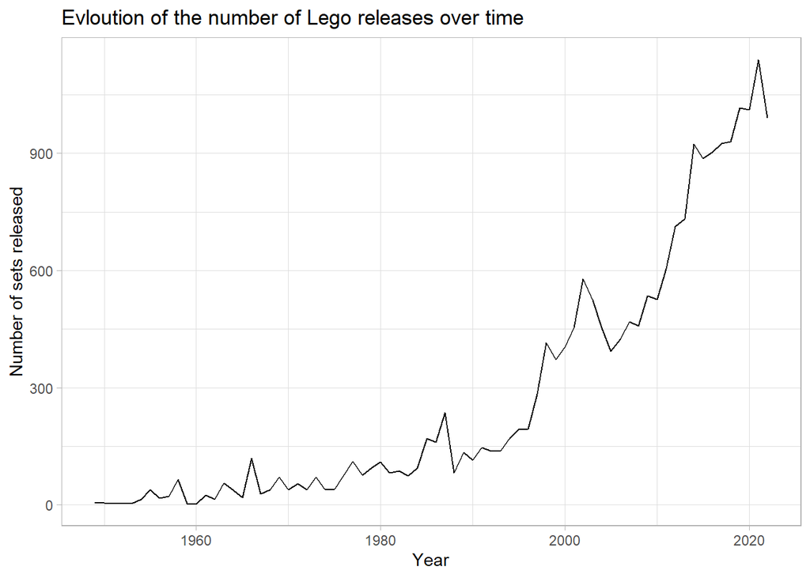

```r
lego$sets %>%
  inner_join(lego$inventories, by = c("set_num" = "set_num")) %>%
  dplyr::filter(year < 2023 & version == 1) %>% # We need to filter version to avoid duplicate releases
  group_by(year) %>%
  count %>%
  ggplot() +
    aes(x = year, y = n) +
    geom_line() +
    labs(x = "Year",
      y = "Number of sets released",
      title = "Evloution of the number of Lego releases over time") +
    theme_light()
```

As we can see, the Lego releases really started to skyrocket after the 90s and globally kept increasing, reaching more than 1100 releases in 2021, even though it sometimes dropped after peak years.

### Evolution of the number of colors used over time:

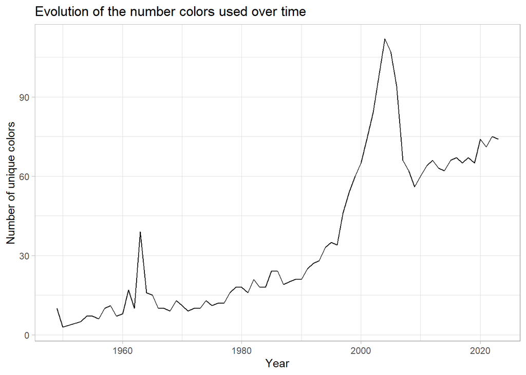

```r
lego$sets %>%
  inner_join(lego$inventories, by = c("set_num" = "set_num")) %>%
  inner_join(lego$inventory_parts, by = c("id" = "inventory_id")) %>%
  select(year, color_id) %>%
  distinct %>%
  group_by(year) %>%
  count %>%
  ggplot() +
    aes(x = year, y = n) +
    geom_line() +
    labs(x = "Year",
         y = "Number of unique colors",
         title = "Evolution of the number colors used over time") +
    theme_light()
```

Surprisingly, the number od unique colors started increasing very sharply around 1995 and peaked at over a hundred in 2004, before brutally decreasing to around 60. The number of unique colors has then been slowly increasing until today.

### Pie chart of most used colors

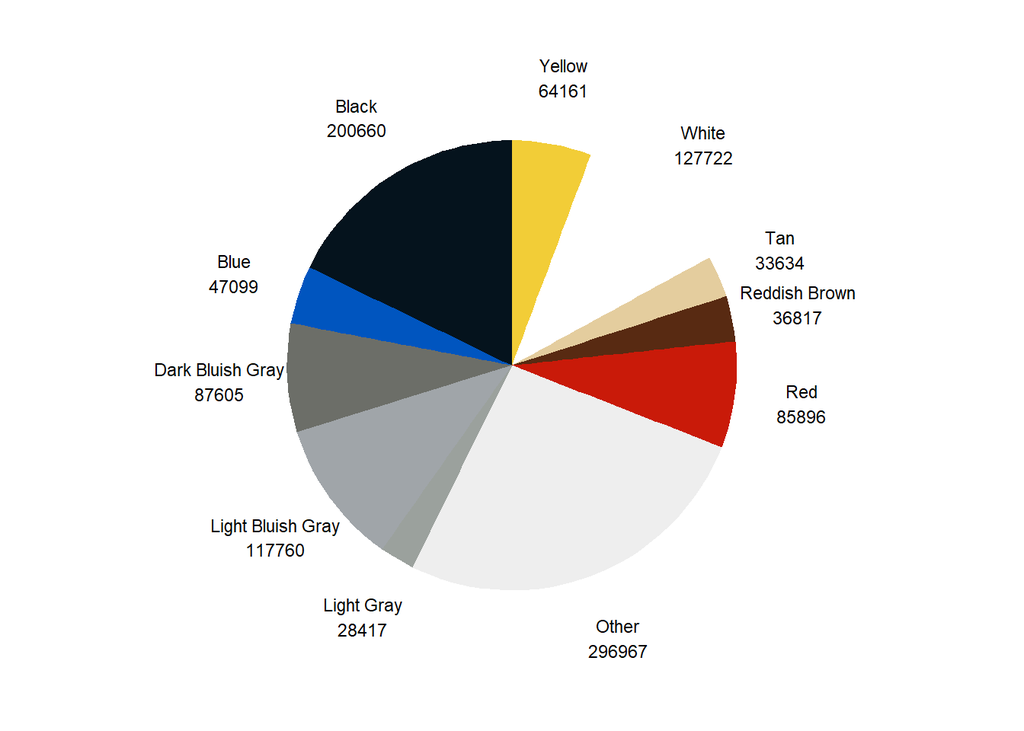

```r
most_used_colors <- lego$inventory_parts %>%
  inner_join(lego$colors, by = c("color_id" = "id")) %>%
  group_by(color_id, name, rgb) %>%
  count %>%
  arrange(desc(n))
most_used_colors <- most_used_colors %>%
  ungroup %>%
  slice_head(n=10) %>%
  add_row(name="Other", rgb="EEEEEE", n=sum(most_used_colors$n)-sum(.$n)) %>%
  arrange(name)
most_used_colors %>%
  ggplot() +
    aes(x = "", y = n, fill = name) +
    geom_bar(stat="identity", width=1) +
    coord_polar("y", start=0) +
    geom_text(aes(label = str_c(name, '\n', as.character(n)), x=1.8), position = position_stack(vjust=0.5), size = 3) +
    scale_fill_manual(values=paste("#", most_used_colors$rgb, sep = "")) +
    guides(fill=FALSE) +
    theme_void()
```

### Evolution of the distribution of the 10 most used colors

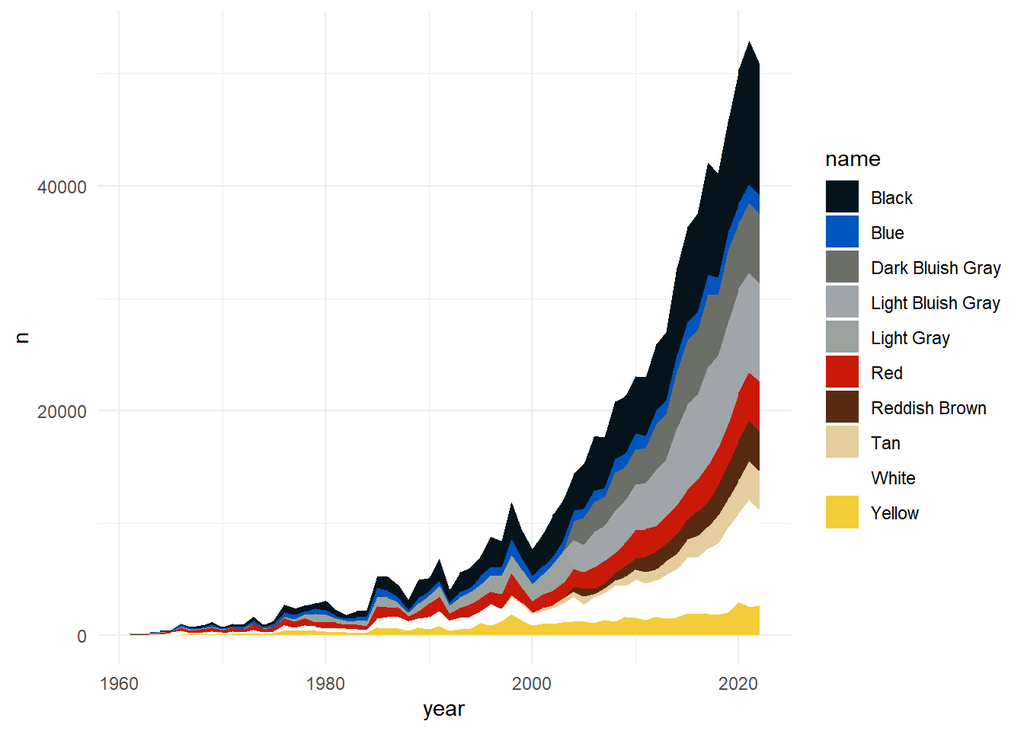

```r
most_used_colors_year <- most_used_colors %>%
  select(color_id, name, rgb) %>%
  inner_join(lego$inventory_parts, by = c("color_id"="color_id")) %>%
  inner_join(lego$inventories, by = c("inventory_id"="id")) %>%
  inner_join(lego$sets, by = c("set_num"="set_num")) %>%
  group_by(name=name.x, rgb, year) %>%
  count %>%
  arrange(name)

most_used_colors_year %>%
  dplyr::filter(year > 1960 & year < 2023) %>%
  ggplot() +
    aes(x = year, y = n, fill = name) +
    geom_area() +
  scale_fill_manual(values=paste("#", unique(most_used_colors_year$rgb), sep = "")) +
    theme_minimal()
```

We can see on this area chart that some of the most used colors in general appeared only after 2000 like the two new shades of gray that replaced the old one, along with Reddish Brown and Tan.

## 5. Conclusion

We have been exploring the statistics around the Lego brand. First, we managed to extract some fun facts using the Rebrickable dataset, for example the sets that have the most parts and data about minifigurines. We also created some useful functions that allow us to retrieve all the parts necessary to build a Lego set and to get the most used parts depending on the Lego theme. We visualized the Rebrickable data and saw that the number of set releases and colors used are globally increasing over the years, which is coherent with the fact that the Lego company is growing years after years Finally, we built two chart related to colors: one shows the distribution of the most used colors and the other shows the evolution of the repartition. Globally, we see that black, white and the shades of gray are the most used colors in general.

## 6. References

“10 TOP LEGO FACTS!” n.d. https://www.natgeokids.com/uk/kids-club/entertainment/general-entertainment/ten-top-lego-facts.

“Lego.” 2023. https://en.wikipedia.org/wiki/Lego.

“LEGO Catalog Database Downloads.” 2023. https://rebrickable.com/downloads.

“Value of the Leading Toy Brands Worldwide in 2023.” 2023. https://www.statista.com/statistics/399131/value-of-the-leading-global-toy-brands.